# Marketing Mix Models

Abhilash K R

2 June 2017

Implementation of MMM in R:

The data we consider here is the dataset used in Chpater 9 of the book ‘Cutting-Edge Marketing Analytics: Real World Cases and Data Sets for Hands On Learning’. The data set is available to download from www.dmanalytics.org.

Importing data

```r
library(xlsx)
data = read.xlsx('MMM.xlsx',sheetIndex = 1)
head(data)
```

```
##   BrandName Brand.ID Year Absolut Aristocrat Barton Belvedere Burnett
## 1   Absolut       15 1995       1          0      0         0       0
## 2   Absolut       15 1996       1          0      0         0       0
## 3   Absolut       15 1997       1          0      0         0       0
## 4   Absolut       15 1998       1          0      0         0       0
## 5   Absolut       15 1999       1          0      0         0       0
## 6   Absolut       15 2000       1          0      0         0       0
##   Chopin Crystal.Palac Finlandia Fleischmann.s Fris Gilbey.s Gordon.s
## 1      0             0         0             0    0        0        0
## 2      0             0         0             0    0        0        0
## 3      0             0         0             0    0        0        0
## 4      0             0         0             0    0        0        0
## 5      0             0         0             0    0        0        0
## 6      0             0         0             0    0        0        0
##   Grey.Goose Kamchatka Ketel.One Level McCormick Polar.Ice Popov Pravda
```

[output cut: 55 more lines]

```r
length(unique(data$BrandName))
```

```
## [1] 27
```

```r
attach(data)
```

This data set includes a total of 27 brands of vodka manufacturing companies. For MMM, let’s choose a brand and analyse the impact of Price on sales. For instance, let’s choose ‘Finlandia’ as the brand for our analysis.

```r
Finlandia = subset(data,BrandName == 'Finlandia')
dim(Finlandia)
```

```
## [1] 13 74
```

```r
print(Finlandia)
```

[output not shown]

[output cut: 139 more lines]

There are a lot of columns not of our interest. Let’s filter them out.

```r
Pr_Finlandia = data.frame(Finlandia$LnSales,Finlandia$LnPrice)
names(Pr_Finlandia) = c('LnSales','LnPrice')
Pr_Finlandia
```

```
##     LnSales  LnPrice
## 1  5.480639 4.987310
## 2  5.393628 4.710717
## 3  5.209486 4.958037
## 4  5.513429 4.727388
## 5  5.529429 4.727388
## 6  5.616771 4.846275
## 7  5.834811 4.837117
## 8  5.765191 4.785819
## 9  5.789960 4.785834
## 10 5.877736 4.872178
## 11 5.899898 4.883922
## 12 5.942800 4.877799
## 13 5.891644 4.909420
```

In order to find the impact of Price on sales,let’s build a regression model on the dataset. First let’s plot some graphs to understand the data points.

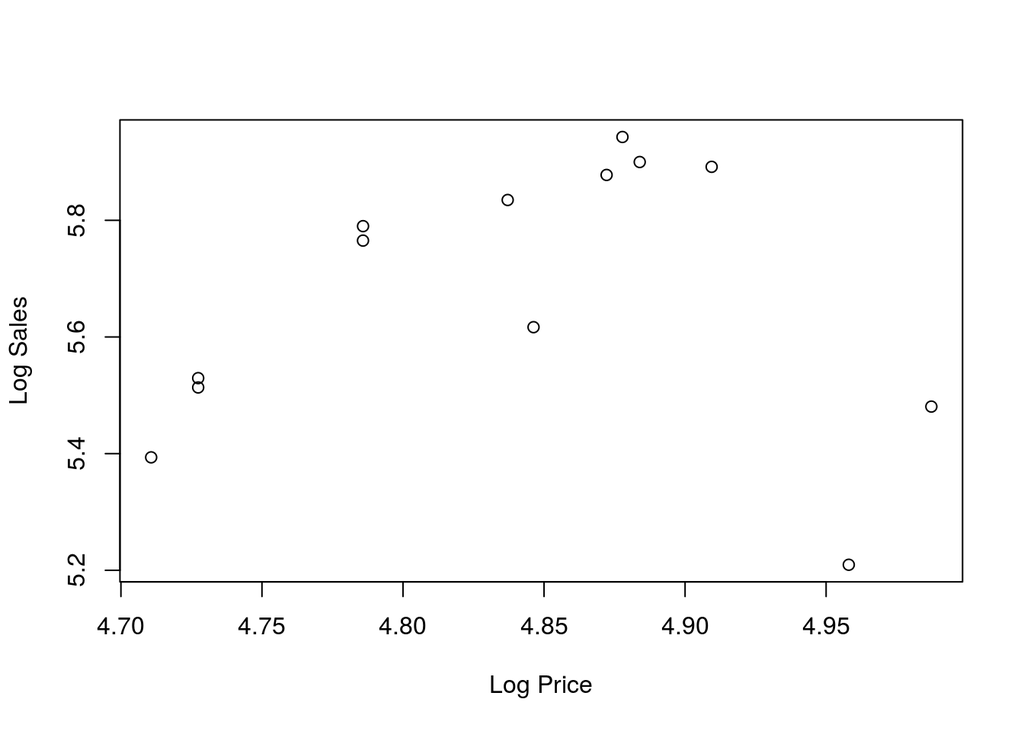

```r
plot( x = Pr_Finlandia$LnPrice,y = Pr_Finlandia$LnSales,xlab = 'Log Price',ylab = 'Log Sales')
```

We can infer that price variation is almost linear in nature with sales with outliers.

We can remove the outliers and therefore fit out regression line.

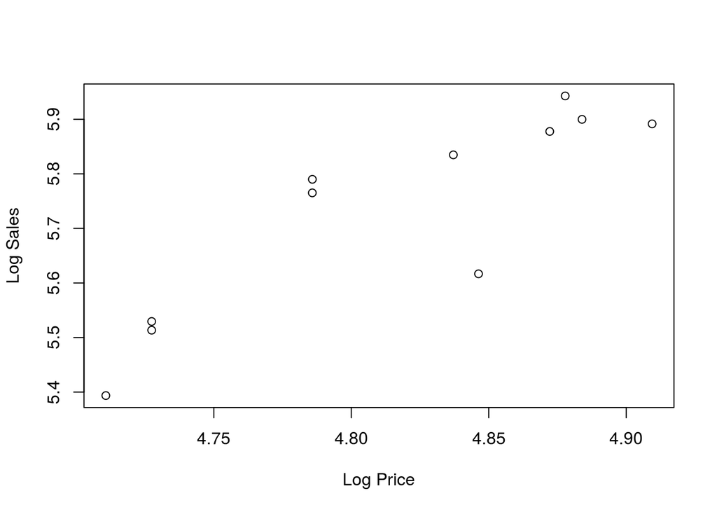

```r
Pr_Finlandia = subset(Pr_Finlandia,LnPrice < 4.95)
plot( x = Pr_Finlandia$LnPrice,y = Pr_Finlandia$LnSales,xlab = 'Log Price',ylab = 'Log Sales')
```

Linear Regression :

```r
result = lm(formula = 'LnSales ~ LnPrice',data = Pr_Finlandia)
summary(result)
```

```
##
## Call:
## lm(formula = "LnSales ~ LnPrice", data = Pr_Finlandia)
##
## Residuals:
##       Min        1Q    Median        3Q       Max
## -0.188187 -0.037886  0.007768  0.057953  0.124954
##
## Coefficients:
##             Estimate Std. Error t value Pr(>|t|)
## (Intercept)  -5.4167     2.0426  -2.652 0.026394 *
## LnPrice       2.3155     0.4242   5.459 0.000401 ***
## ---
## Signif. codes:  0 '***' 0.001 '**' 0.01 '*' 0.05 '.' 0.1 ' ' 1
##
## Residual standard error: 0.09511 on 9 degrees of freedom
## Multiple R-squared:  0.768,  Adjusted R-squared:  0.7423
## F-statistic:  29.8 on 1 and 9 DF,  p-value: 0.000401
```

Here, the p-value of price is almost zero that indicates that price is significant indicator of sales. Here, the value of R-squared is 0.768 i.e the price variable indicates nearly 77% of the data points. The co-efficient of price tells that for every unit increase in price, there is 2.31 times increase in sales. Let’s add more variables to the regression and see what happens with the R-squared.

```r
Ad_Finlandia = subset(Finlandia,select = c('LnSales','LnMag','LnNews','LnOut','LnBroad','LnPrint','LnPrice'))
dim(Ad_Finlandia)
```

```
## [1] 13  7
```

```r
Ad_Finlandia
```

```
##     LnSales    LnMag     LnNews     LnOut  LnBroad  LnPrint  LnPrice
## 78 5.480639 0.000000  0.0000000 0.0000100 0.000010 5.459586 4.987310
## 79 5.393628 0.000000  0.0000000 0.0000100 0.000010 0.000010 4.710717
## 80 5.209486 7.788294 -0.9162907 0.5877866 0.000010 7.788460 4.958037
## 81 5.513429 9.006558  4.5020290 6.3554130 5.786591 9.017556 4.727388
## 82 5.529429 8.535426  6.0031460 5.0625950 5.608739 8.611903 4.727388
## 83 5.616771 7.224098  6.5250300 5.7077750 1.757858 7.627593 4.846275
## 84 5.834811 5.964093  5.9814140 4.0036900 0.000010 6.665938 4.837117
## 85 5.765191 6.539731  4.7256160 3.0910430 0.000010 6.690718 4.785819
## 86 5.789960 6.629231  0.0000000 0.0000100 0.000010 6.630551 4.785834
## 87 5.877736 5.119789  5.2390980 3.8979240 0.000010 5.874369 4.872178
## 88 5.899898 7.284615  5.3922630 4.5250440 0.000010 7.425000 4.883922
## 89 5.942800 8.687222  0.0000000 5.3042990 5.304299 8.687391 4.877799
## 90 5.891644 8.902551  0.0000000 5.6991050 4.784988 8.902687 4.909420
```

```r
result_ad = lm(formula ='LnSales ~ LnMag + LnNews + LnOut + LnBroad + LnPrint + LnPrice',data=Ad_Finlandia)
summary(result_ad)
```

```
##
## Call:
## lm(formula = "LnSales ~ LnMag + LnNews + LnOut + LnBroad + LnPrint + LnPrice",
##     data = Ad_Finlandia)
##
## Residuals:
##      Min       1Q   Median       3Q      Max
## -0.28787 -0.06936  0.03921  0.13734  0.19446
##
## Coefficients:
##             Estimate Std. Error t value Pr(>|t|)
## (Intercept) 16.30608    9.98348   1.633   0.1535
## LnMag       -0.07663    0.08489  -0.903   0.4015
## LnNews      -0.10075    0.06977  -1.444   0.1988
## LnOut        0.21095    0.10703   1.971   0.0962 .
## LnBroad     -0.16092    0.09485  -1.697   0.1407
## LnPrint      0.12320    0.12571   0.980   0.3649
## LnPrice     -2.30179    2.12122  -1.085   0.3195
## ---
## Signif. codes:  0 '***' 0.001 '**' 0.01 '*' 0.05 '.' 0.1 ' ' 1
##
## Residual standard error: 0.231 on 6 degrees of freedom
## Multiple R-squared:  0.5011, Adjusted R-squared:  0.002126
## F-statistic: 1.004 on 6 and 6 DF,  p-value: 0.498
```

```r
result_inter = lm('LnSales ~ LnMag + LnNews + LnOut * LnBroad + LnPrint + LnPrice',data=Ad_Finlandia)
summary(result_inter)
```

```
##
## Call:
## lm(formula = "LnSales ~ LnMag + LnNews + LnOut * LnBroad + LnPrint + LnPrice",
##     data = Ad_Finlandia)
##
## Residuals:
##        78        79        80        81        82        83        84
## -0.016749 -0.036166 -0.075965  0.019294  0.017785 -0.165698  0.019895
##        85        86        87        88        89        90
## -0.141204  0.103224  0.207687  0.051581  0.003465  0.012852
##
## Coefficients:
##               Estimate Std. Error t value Pr(>|t|)
## (Intercept)   30.47222    7.98562   3.816  0.01243 *
## LnMag         -0.18276    0.06526  -2.800  0.03798 *
## LnNews        -0.20077    0.05600  -3.585  0.01579 *
## LnOut          0.36721    0.08646   4.247  0.00811 **
## LnBroad        0.28660    0.15967   1.795  0.13261
## LnPrint        0.28170    0.09688   2.908  0.03349 *
## LnPrice       -5.31606    1.69756  -3.132  0.02591 *
## LnOut:LnBroad -0.10413    0.03428  -3.038  0.02882 *
## ---
## Signif. codes:  0 '***' 0.001 '**' 0.01 '*' 0.05 '.' 0.1 ' ' 1
##
## Residual standard error: 0.15 on 5 degrees of freedom
## Multiple R-squared:  0.8247, Adjusted R-squared:  0.5792
## F-statistic:  3.36 on 7 and 5 DF,  p-value: 0.1004
```

Boom! The results here are surprised. The presence of significant interaction indicates that the effect of one predictor variable on the response variable is different at different values of the other predictor variable. Therefore,the individial effects of the predictors also include the effects of the co-efficients of the interaction terms.

The R-squared value has also increased indicating the model can explain most of the data points now.